# 04-pavonado

### Pavonado

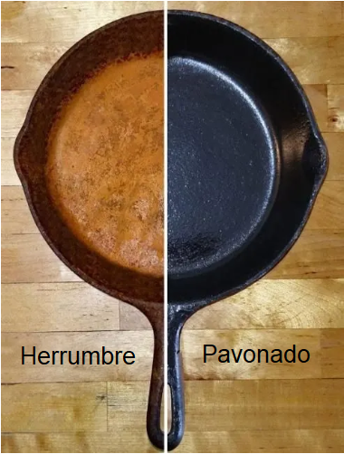

Fuente: pinterest.com

**El herrumbre** (óxido rojo) es un tipo de óxido que se forma en presencia de oxígeno y humedad, es poroso y por eso continúa avanzando y termina degradando y desintegrando el acero.

**El pavonado** es otro tipo de óxido que forma una capa protectora que no permite que el metal se herrumbre.

El proceso tradicional de pavonar con aceite es muy antiguo y consiste en:

- Calentar la pieza a unos 300°c
- Sumergirla en cualquier tipo de aceite (o pasarle un trapo con aceite por toda su superficie caliente).
- Repetir el proceso si es necesario

[figure not shown]

> **Importante:** Se debe tener precaución con el fuego. Nunca tirar alcohol directamente a la llama. Conocer el uso del matafuego y tenerlo a mano.

**Actividad**

Dibujar el proceso de pavonado y responde esta pregunta: ¿Cómo se estima la temperatura de la pieza si instrumentos?